# Student_mental_health_analysis

2026-05-07

# Introduction

The motivation for this project was inspired by the EUROSTUDENT VIII report on student well-being in the European Higher Education Area, which highlights the growing concerns regarding mental health issues among university students across Europe. The report discusses how factors such as academic pressure, financial difficulties, social conditions, and personal circumstances influence student well-being and mental health. Based on these findings, this project aims to perform an exploratory data analysis on a student mental health dataset using R. The objective is to identify patterns and relationships between demographic and academic factors and mental health indicators such as depression, anxiety, and panic attacks.

```r
library(janitor)
```

```r
library(ggplot2)
```

## Loading dataset

```r
data_set <- read.csv("C:/Users/HP/Desktop/Projects/Dataset/Student Mental health.csv")
```

## Dataset Dimensions

```r
dim(data_set)
```

```
## [1] 101  11
```

## Dataset Structure

```r
str(data_set)
```

```
## 'data.frame':    101 obs. of  11 variables:
##  $ Timestamp                                   : chr  "8/7/2020 12:02" "8/7/2020 12:04" "8/7/2020 12:05" "8/7/2020 12:06" ...
##  $ Choose.your.gender                          : chr  "Female" "Male" "Male" "Female" ...
##  $ Age                                         : int  18 21 19 22 23 19 23 18 19 18 ...
##  $ What.is.your.course.                        : chr  "Engineering" "Islamic education" "BIT" "Laws" ...
##  $ Your.current.year.of.Study                  : chr  "year 1" "year 2" "Year 1" "year 3" ...
##  $ What.is.your.CGPA.                          : chr  "3.00 - 3.49" "3.00 - 3.49" "3.00 - 3.49" "3.00 - 3.49" ...
##  $ Marital.status                              : chr  "No" "No" "No" "Yes" ...
##  $ Do.you.have.Depression.                     : chr  "Yes" "No" "Yes" "Yes" ...
##  $ Do.you.have.Anxiety.                        : chr  "No" "Yes" "Yes" "No" ...
##  $ Do.you.have.Panic.attack.                   : chr  "Yes" "No" "Yes" "No" ...
##  $ Did.you.seek.any.specialist.for.a.treatment.: chr  "No" "No" "No" "No" ...
```

## Summary Statistics

```r
summary(data_set)
```

```
##   Timestamp         Choose.your.gender      Age        What.is.your.course.
##  Length:101         Length:101         Min.   :18.00   Length:101
##  Class :character   Class :character   1st Qu.:18.00   Class :character
##  Mode  :character   Mode  :character   Median :19.00   Mode  :character
##                                        Mean   :20.53
##                                        3rd Qu.:23.00
##                                        Max.   :24.00
##                                        NA's   :1
##  Your.current.year.of.Study What.is.your.CGPA. Marital.status
##  Length:101                 Length:101         Length:101
##  Class :character           Class :character   Class :character
##  Mode  :character           Mode  :character   Mode  :character
##
##
##
##
##  Do.you.have.Depression. Do.you.have.Anxiety. Do.you.have.Panic.attack.
##  Length:101              Length:101           Length:101
##  Class :character        Class :character     Class :character
##  Mode  :character        Mode  :character     Mode  :character
##
##
##
##
##  Did.you.seek.any.specialist.for.a.treatment.
##  Length:101
##  Class :character
##  Mode  :character
##
##
##
##
```

## Cleaning Dataset

```r
data_set<-clean_names(data_set)
colnames(data_set)
```

```
##  [1] "timestamp"
##  [2] "choose_your_gender"
##  [3] "age"
##  [4] "what_is_your_course"
##  [5] "your_current_year_of_study"
##  [6] "what_is_your_cgpa"
##  [7] "marital_status"
##  [8] "do_you_have_depression"
##  [9] "do_you_have_anxiety"
## [10] "do_you_have_panic_attack"
## [11] "did_you_seek_any_specialist_for_a_treatment"
```

### Checking for Null values

```r
colSums(is.na(data_set))
```

```
##                                   timestamp
##                                           0
##                          choose_your_gender
##                                           0
##                                         age
##                                           1
##                         what_is_your_course
##                                           0
##                  your_current_year_of_study
##                                           0
##                           what_is_your_cgpa
##                                           0
##                              marital_status
##                                           0
##                      do_you_have_depression
##                                           0
##                         do_you_have_anxiety
##                                           0
##                    do_you_have_panic_attack
##                                           0
## did_you_seek_any_specialist_for_a_treatment
##                                           0
```

There is only one Null value in the column age, we can just omit that value ### omiting Null value

```r
data_set<-na.omit(data_set)
df<-data_set
```

## Number of students suffering from Depression

```r
table(df$do_you_have_depression)
```

```
##
##  No Yes
##  65  35
```

## Number of students suffering from anxiety

```r
table(df$do_you_have_anxiety)
```

```
##
##  No Yes
##  66  34
```

## Number of people having panic attacks

```r
table(df$do_you_have_panic_attack)
```

```
##
##  No Yes
##  67  33
```

## Gender vs depression

```r
table(df$choose_your_gender,df$do_you_have_depression)
```

```
##
##          No Yes
##   Female 46  29
##   Male   19   6
```

## plot

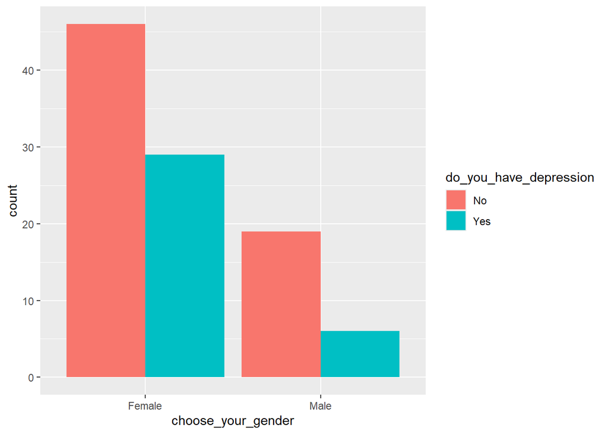

```r
ggplot(df,
       aes(x=choose_your_gender,
           fill=do_you_have_depression))+
  geom_bar(position = "dodge")
```

## Percentage analysis

```r
round(prop.table(table(df$choose_your_gender, df$do_you_have_depression), margin = 1)*100,2)
```

```
##
##             No   Yes
##   Female 61.33 38.67
##   Male   76.00 24.00
```

## chisquare test

```r
chisq.test(table(df$choose_your_gender,df$do_you_have_depression))
```

```
##
##  Pearson's Chi-squared test with Yates' continuity correction
##
## data:  table(df$choose_your_gender, df$do_you_have_depression)
## X-squared = 1.1868, df = 1, p-value = 0.276
```

From the comparison of gender and depression we can conclude that depression is slightly higher in females compared to males. However, the chi-square test produced a p-value greater than 0.05, indicating that the association between gender and depression is not statistically significant in this dataset. ## Course vs Depression

```r
  table(df$what_is_your_course,df$do_you_have_depression)
```

```
##
##                           No Yes
##   Accounting               1   0
##   ALA                      0   1
##   Banking Studies          1   0
##   BCS                     13   5
##   Benl                     1   0
##   BENL                     0   2
##   Biomedical science       4   0
##   Biotechnology            1   0
##   BIT                      4   5
##   Business Administration  1   0
##   Communication            0   1
##   CTS                      1   0
##   Diploma Nursing          1   0
##   DIPLOMA TESL             1   0
##   Econs                    0   1
##   engin                    1   0
##   Engine                   2   0
##   Engineering             10   7
##   ENM                      0   1
##   Fiqh                     1   0
##   Fiqh fatwa               1   0
##   Human Resources          1   0
##   Human Sciences           1   0
##   Irkhs                    1   0
##   Islamic education        1   0
##   Islamic Education        1   0
##   IT                       1   0
##   KENMS                    1   0
##   Kirkhs                   1   0
##   KIRKHS                   1   0
##   koe                      0   1
##   Koe                      1   0
##   KOE                      3   1
##   Kop                      1   0
##   Law                      0   1
##   Laws                     1   1
##   Malcom                   0   1
##   Marine science           0   1
##   Mathemathics             1   0
##   MHSC                     0   1
##   Nursing                  0   1
##   Pendidikan islam         0   1
##   Pendidikan Islam         1   0
##   Pendidikan Islam         1   0
##   psychology               0   2
##   Psychology               1   0
##   Radiography              1   0
##   TAASL                    1   0
##   Usuluddin                0   1
```

## Percentage analysis

```r
round(prop.table(table(df$what_is_your_course, df$do_you_have_depression), margin = 1)*100,2)
```

```
##
##                               No    Yes
##   Accounting              100.00   0.00
##   ALA                       0.00 100.00
##   Banking Studies         100.00   0.00
##   BCS                      72.22  27.78
##   Benl                    100.00   0.00
##   BENL                      0.00 100.00
##   Biomedical science      100.00   0.00
##   Biotechnology           100.00   0.00
##   BIT                      44.44  55.56
##   Business Administration 100.00   0.00
##   Communication             0.00 100.00
##   CTS                     100.00   0.00
##   Diploma Nursing         100.00   0.00
##   DIPLOMA TESL            100.00   0.00
##   Econs                     0.00 100.00
##   engin                   100.00   0.00
##   Engine                  100.00   0.00
##   Engineering              58.82  41.18
##   ENM                       0.00 100.00
##   Fiqh                    100.00   0.00
##   Fiqh fatwa              100.00   0.00
##   Human Resources         100.00   0.00
##   Human Sciences          100.00   0.00
##   Irkhs                   100.00   0.00
##   Islamic education       100.00   0.00
##   Islamic Education       100.00   0.00
##   IT                      100.00   0.00
##   KENMS                   100.00   0.00
##   Kirkhs                  100.00   0.00
##   KIRKHS                  100.00   0.00
##   koe                       0.00 100.00
##   Koe                     100.00   0.00
##   KOE                      75.00  25.00
##   Kop                     100.00   0.00
##   Law                       0.00 100.00
##   Laws                     50.00  50.00
##   Malcom                    0.00 100.00
##   Marine science            0.00 100.00
##   Mathemathics            100.00   0.00
##   MHSC                      0.00 100.00
##   Nursing                   0.00 100.00
##   Pendidikan islam          0.00 100.00
##   Pendidikan Islam        100.00   0.00
##   Pendidikan Islam        100.00   0.00
##   psychology                0.00 100.00
##   Psychology              100.00   0.00
##   Radiography             100.00   0.00
##   TAASL                   100.00   0.00
##   Usuluddin                 0.00 100.00
```

Due to the large number of course categories and small sample counts in certain groups, the chi-square approximation may be unreliable for this comparison.

## Finding the unique bins for cgpa

```r
unique(df$what_is_your_cgpa)
```

```
## [1] "3.00 - 3.49"  "3.50 - 4.00"  "3.50 - 4.00 " "2.50 - 2.99"  "2.00 - 2.49"
## [6] "0 - 1.99"
```

## customized bins

```r
df$cgpa_grp<-ifelse(df$what_is_your_cgpa %in% c("0 - 1.99","2.00 - 2.49"), "0-2.5",
                      ifelse(df$what_is_your_cgpa == "2.50 - 2.99",
                             "2.5-3.0",
                            "3.0-4.0"))
```

## CGPA vs depression

```r
table(df$cgpa_grp,df$do_you_have_depression)
```

```
##
##           No Yes
##   0-2.5    5   0
##   2.5-3.0  1   3
##   3.0-4.0 59  32
```

## percentage analysis

```r
round(prop.table(table(df$cgpa_grp,df$do_you_have_depression), margin=1)*100,2)
```

```
##
##               No    Yes
##   0-2.5   100.00   0.00
##   2.5-3.0  25.00  75.00
##   3.0-4.0  64.84  35.16
```

## Plot

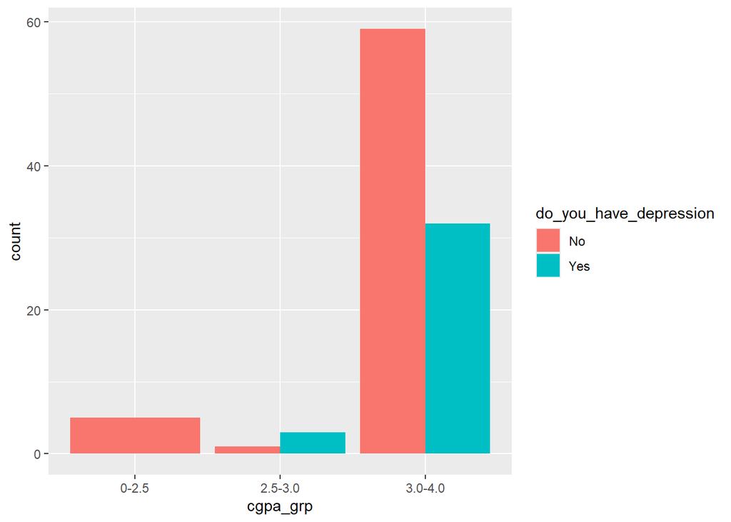

```r
ggplot(df, aes(x=cgpa_grp,
               fill=do_you_have_depression))+
  geom_bar(position = "dodge")
```

Lower CGPA categories contained very few observations, so conclusions from these groups should be interpreted cautiously.

## age vs Depression

```r
table(df$age,df$do_you_have_depression)
```

```
##
##      No Yes
##   18 21  11
##   19 12   9
##   20  3   3
##   21  3   0
##   22  1   1
##   23  8   5
##   24 17   6
```

## percentage analysis

```r
round(prop.table(table(df$age,df$do_you_have_depression),margin = 1)*100,2)
```

```
##
##          No    Yes
##   18  65.62  34.38
##   19  57.14  42.86
##   20  50.00  50.00
##   21 100.00   0.00
##   22  50.00  50.00
##   23  61.54  38.46
##   24  73.91  26.09
```

## Plots

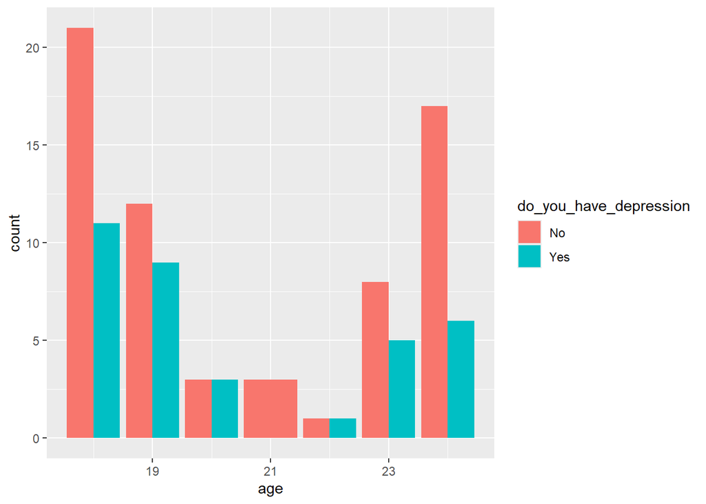

```r
ggplot(df, aes(x=age,
               fill=do_you_have_depression))+
  geom_bar(position = "dodge")
```

## Marital status vs depression

```r
table(df$marital_status,df$do_you_have_depression)
```

```
##
##       No Yes
##   No  65  19
##   Yes  0  16
```

## Percentage analysis

```r
round(prop.table(table(df$marital_status,df$do_you_have_depression),margin = 1)*100,2)
```

```
##
##           No    Yes
##   No   77.38  22.62
##   Yes   0.00 100.00
```

## chisquare

```r
chisq.test(table(df$marital_status,df$do_you_have_depression))
```

```
##
##  Pearson's Chi-squared test with Yates' continuity correction
##
## data:  table(df$marital_status, df$do_you_have_depression)
## X-squared = 32.055, df = 1, p-value = 1.499e-08
```

The chi-square test indicated a statistically significant association between marital status and depression (p < 0.05). In this dataset, all married participants reported depression. However, the number of married individuals was very small, so broader conclusions cannot be made from this result alone. ## Anxiety vs depression

```r
table(df$do_you_have_anxiety,df$do_you_have_depression)
```

```
##
##       No Yes
##   No  49  17
##   Yes 16  18
```

## Chisquare test

```r
chisq.test(table(df$do_you_have_anxiety,df$do_you_have_depression))
```

```
##
##  Pearson's Chi-squared test with Yates' continuity correction
##
## data:  table(df$do_you_have_anxiety, df$do_you_have_depression)
## X-squared = 6.1429, df = 1, p-value = 0.01319
```

The chi-square test indicates a statistically significant association between anxiety and depression in this dataset, suggesting that students reporting anxiety were more likely to also report depression.

## Deprssion vs panic attck

```r
table(df$do_you_have_depression,df$do_you_have_panic_attack)
```

```
##
##       No Yes
##   No  49  16
##   Yes 18  17
```

## chi-square test

```r
chisq.test(table(df$do_you_have_panic_attack,df$do_you_have_depression))
```

```
##
##  Pearson's Chi-squared test with Yates' continuity correction
##
## data:  table(df$do_you_have_panic_attack, df$do_you_have_depression)
## X-squared = 4.8712, df = 1, p-value = 0.02731
```

Students who reported panic attacks also showed a higher prevalence of depression compared to students without panic attacks.The chi-square test further indicated that the association between panic attacks and depression was statistically significant (p < 0.05).

## anxiety vs panic attack

```r
table(df$do_you_have_anxiety,df$do_you_have_panic_attack)
```

```
##
##       No Yes
##   No  46  20
##   Yes 21  13
```

# Conclusion

This project explored patterns associated with student mental health using exploratory data analysis and statistical testing in R. The analysis focused on factors such as gender, age, CGPA, marital status, anxiety, and panic attacks in relation to depression among students.

The project also demonstrated important data science processes including data cleaning, handling missing values, feature engineering, exploratory data analysis, percentage analysis, visualization, and chi-square hypothesis testing. Overall, this analysis highlights how data analytics can be used to better understand patterns in student mental health and support future research in this area.